# LCA*: Past Analyses

Niels Hanson

November 28, 2014

Here I’ve put some previous analyses for posterity’s sake.

#### Formatting for R

- `create_analysis_table.py` summarizes results into a Long Table format that can be processed by R:

[output not shown]

- example output:

```
shebop:lca_star_test nielsh$ head first_test.txt
contig  real    taxa    method  dist
lca_star_test1_378  Desulfovibrio desulfuricans subsp. desulfuricans str. ATCC 27774    Desulfomonas Moore et al. 1976  LCA_Star    3
lca_star_test1_378  Desulfovibrio desulfuricans subsp. desulfuricans str. ATCC 27774    all Majority    11
lca_star_test1_378  Desulfovibrio desulfuricans subsp. desulfuricans str. ATCC 27774    biota   LCA_Squared 10
lca_star_test1_379  Desulfovibrio desulfuricans subsp. desulfuricans str. ATCC 27774    Vibrio cholinicus   LCA_Star    2
lca_star_test1_379  Desulfovibrio desulfuricans subsp. desulfuricans str. ATCC 27774    Vibrio cholinicus   Majority    2
lca_star_test1_379  Desulfovibrio desulfuricans subsp. desulfuricans str. ATCC 27774    Desulfomonas Moore et al. 1976  LCA_Squared 3
lca_star_test1_372  Desulfovibrio desulfuricans subsp. desulfuricans str. ATCC 27774    Desulfomonas Moore et al. 1976  LCA_Star    3
lca_star_test1_372  Desulfovibrio desulfuricans subsp. desulfuricans str. ATCC 27774    all Majority    11
lca_star_test1_372  Desulfovibrio desulfuricans subsp. desulfuricans str. ATCC 27774    'Desulfovibrionaceae'   LCA_Squared 4
```

- a function `lcastar.get_distance(taxon, real)` was added to the LCAStar.py class to calculate a simple distance between taxa.

### Preliminary statistics

First, load required libraries.

#### First test

Here compared our first implementation (March 16 2014) of LCA* using the `lca_star_test1.fasta` above (10,000, sampling 10 sequences per file on a random subset of 100):

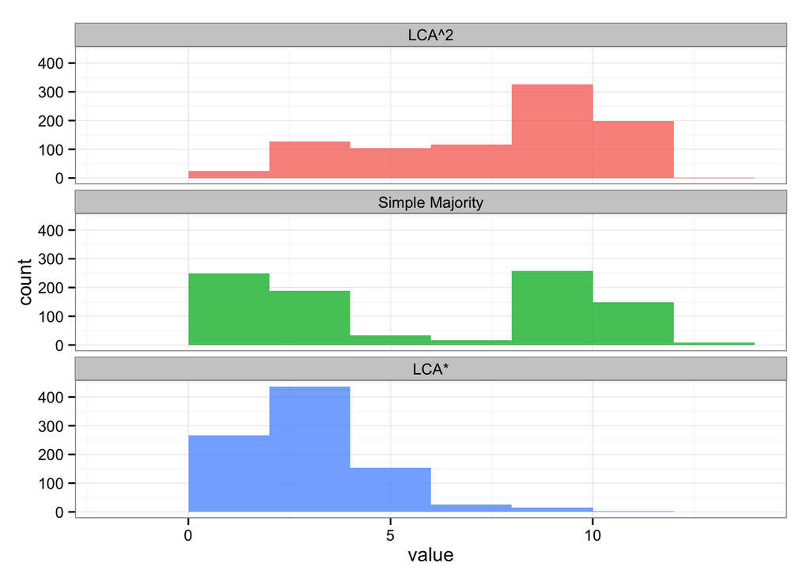

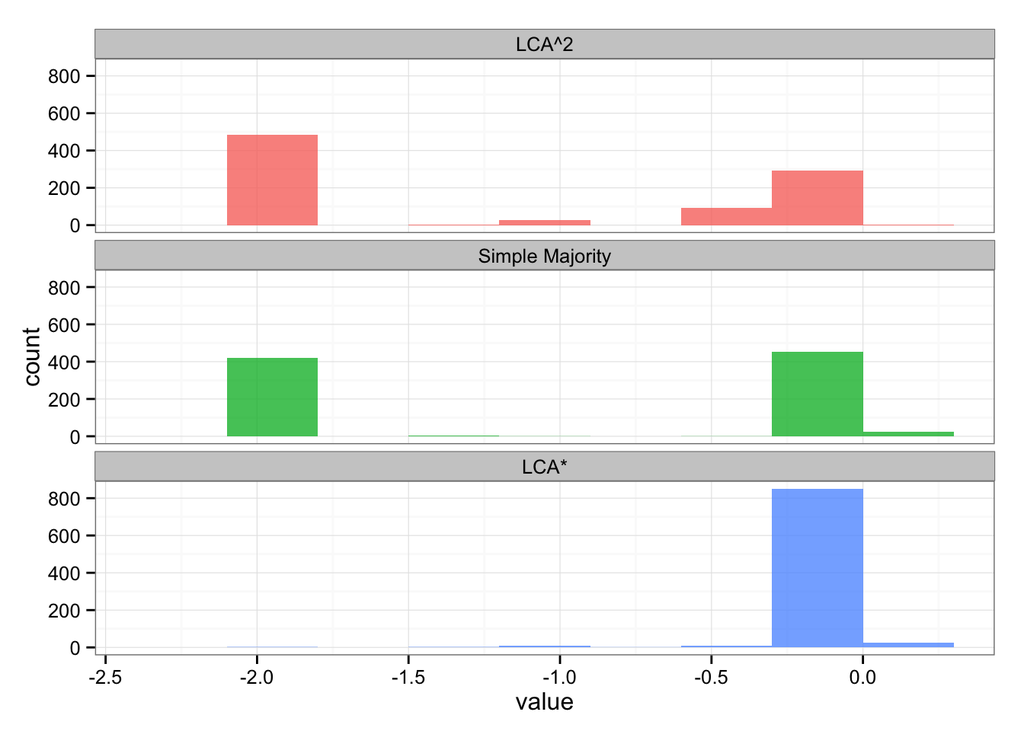

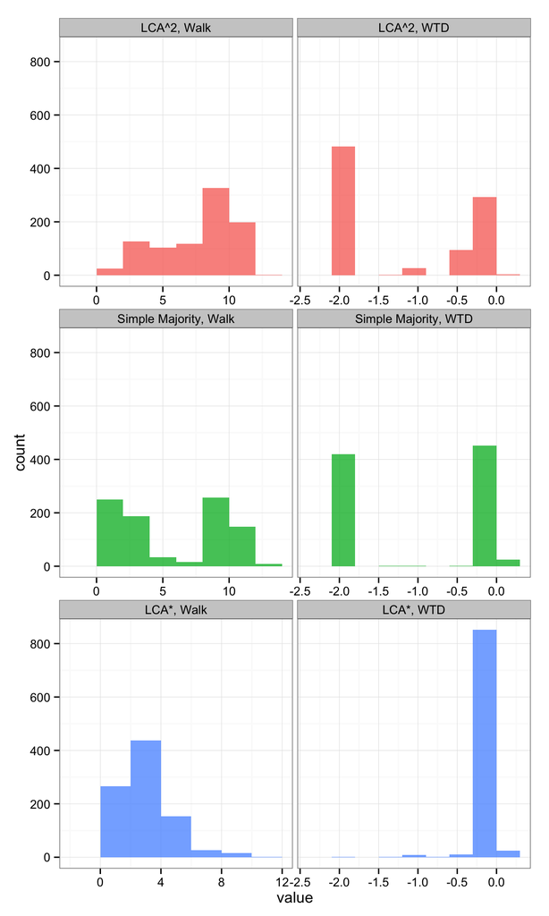

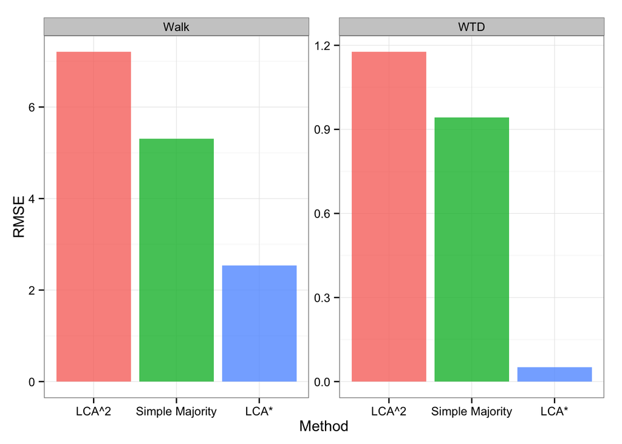

### Notes

- The results are encouraging as LCA star seems to have ‘significantly’ smaller distances compared to the other two methods, meaning it is more specific. Though this first distance metric a small distance might still be divergent which we would like to keep track off.
- Doing some basic delcation by taxa we see that within taxonomic groups LCA* seems to do better on this small subset, however, in some cases, namely Green sulfur bacteria and actinobacteria LCA* was outperformed by the simple Majority rule.
- Here it would be interesting to compare their divergence, as it is conseavable that a simple majority make quite have significant divergence when wrong and having extreme wins when it is correct.

[output not shown]

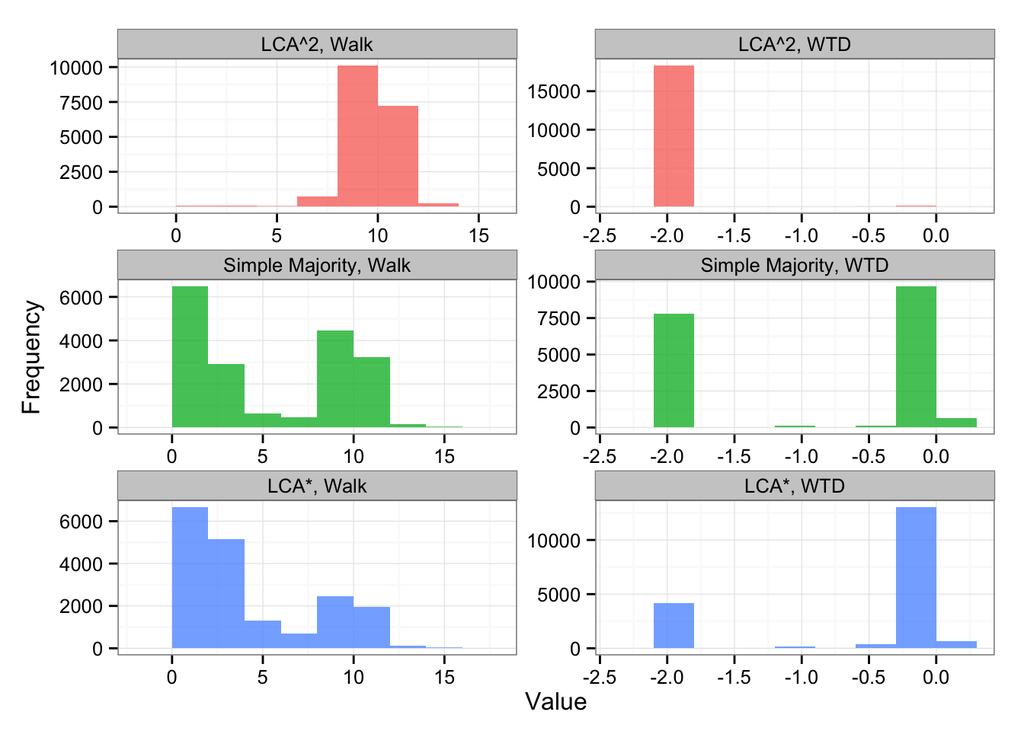

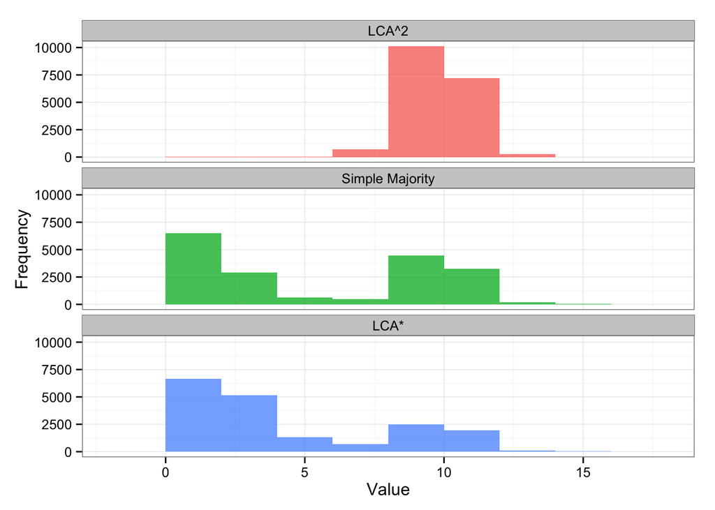

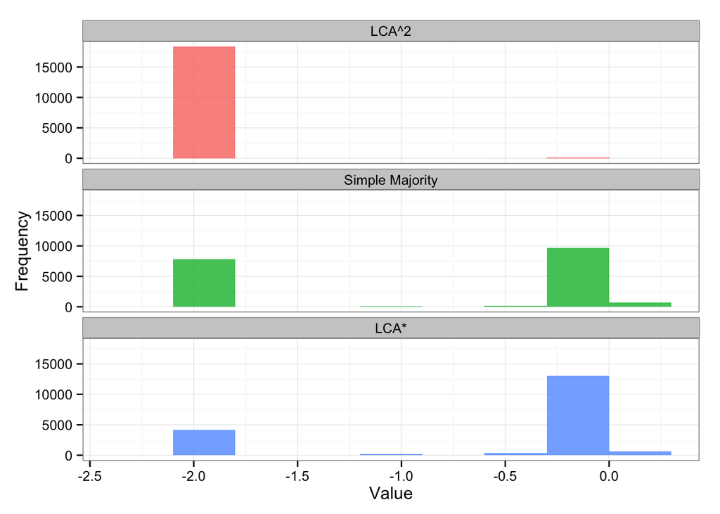

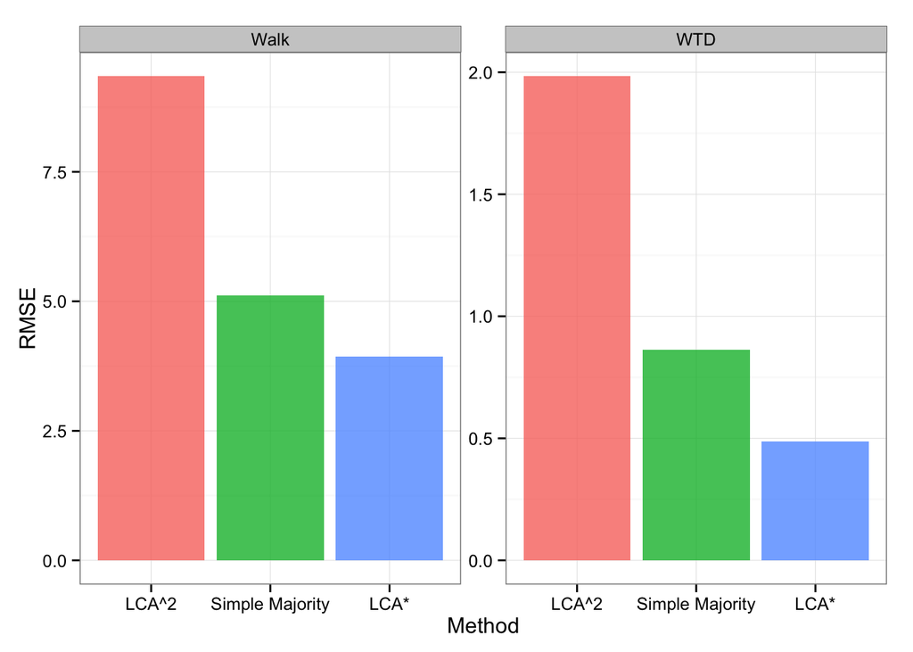